**SYS 6018 | Fall 2020 | University of Virginia**

### Problem 5.1 Geographic Profiling

Geographic profiling, a method developed in criminology, can be used to estimate the [home location (roost) of animals](https://www.sciencedirect.com/science/article/pii/S0022519305004157) based on a collection of sightings. The approach requires an estimate of the distribution the animal will travel from their roost to forage for food.

A sample of $283$ distances that pipistrelle bats traveled (in meters) from their roost can be found at: https://mdporter.github.io/SYS6018/data/geo_profile.csv

One probability model for the distance these bats will travel is:

$$\begin{align*}
f(x; \theta) = \frac{x}{\theta} \exp \left( - \frac{x^2}{2 \theta} \right)
\end{align*}$$
where the parameter $\theta > 0$ controls how far they are willing to travel.

1. Derive the MLE for $\theta$ (i.e., show the math).

```r
data <- read.csv("geo_profile.csv")
```

$$= \frac{\mathrm{d}}{\mathrm{d} x}\left[\frac{x}{\theta} \mathrm{e}^{-\frac{x^{2}}{2 \theta}}\right]$$

$$= \frac{\mathrm{d}}{\mathrm{d} x}\left[\frac{x \mathrm{e}^{-\frac{x^{2}}{2 \theta}}}{\theta}\right]$$

$$=\frac{1}{\theta} \cdot \frac{\mathrm{d}}{\mathrm{d} x}\left[x \mathrm{e}^{-\frac{x^{2}}{2 \theta}}\right]$$

$$=\frac{\frac{\mathrm{d}}{\mathrm{d} x}[x] \cdot \mathrm{e}^{-\frac{x^{2}}{2 \theta}}+x \cdot \frac{\mathrm{d}}{\mathrm{d} x}\left[\mathrm{e}^{-\frac{x^{2}}{2 \theta}}\right]}{\theta}$$

$$=\frac{\mathrm{e}^{-\frac{x^{2}}{2 \theta}}-\frac{x^{2} \mathrm{e}^{-\frac{x^{2}}{2 \theta}}}{\theta}}{\theta}$$

$$MLE= -\frac{\left(x^{2}-\theta\right) e^{-\frac{x^{2}}{2 \theta}}}{\theta^{2}}$$

2. What is the MLE of $\theta$ for the bat data? (Use results from a, or use computational methods.)

```r
theta_seq = seq(0, 10, length=200)  # from density.R
loglike = sapply(theta_seq, function(theta) prod((data[,1]/theta) * exp(-(data[,1]^2 /(2*theta)))))
theta_max = theta_seq[which.max(loglike)] # from density.R
theta_max
```

```
#> [1] 4.522613
```

the MLE of the theta for bata data is 4.522613

3. Using the MLE value of $\theta$ from part b, compute the estimated density of this distribution at a set of evaluation points between 0 and 8 meters. Plot the estimated density.

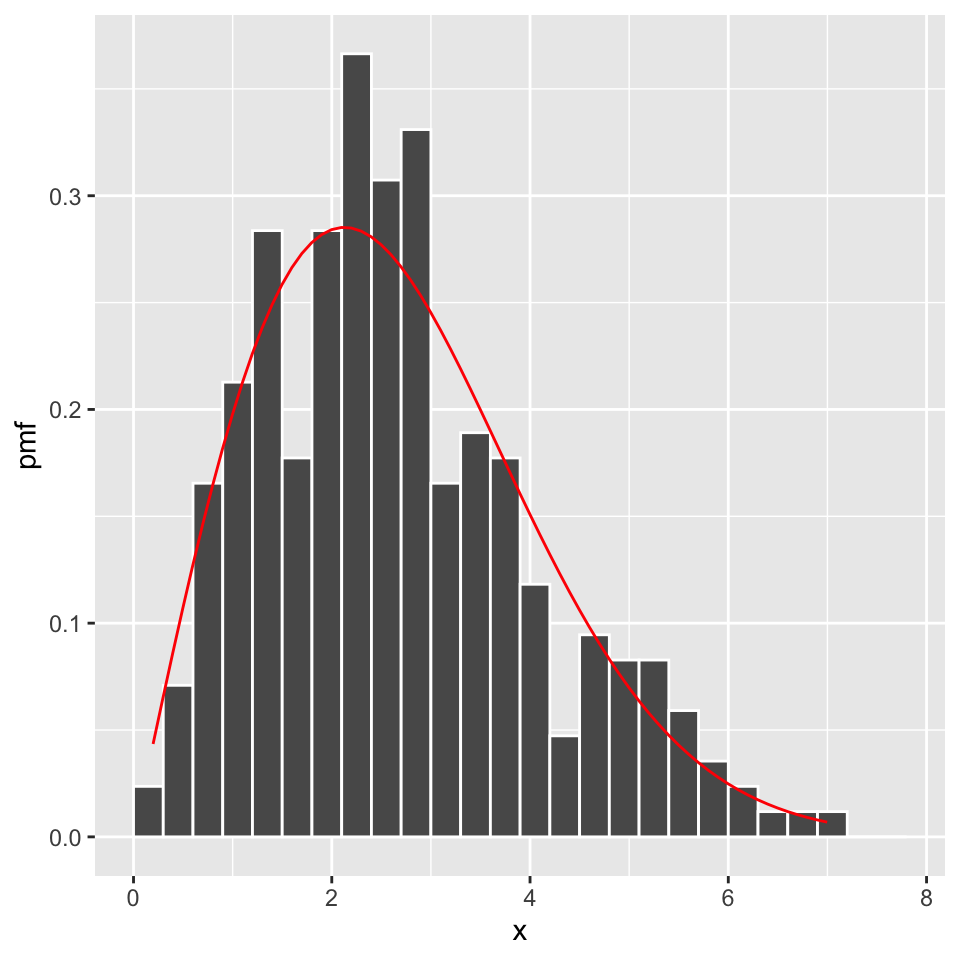

```r
bw = 0.3
bks = seq(0, 8, by=bw)
x = data[,1]
model = tibble(x=seq(min(x), max(x), by=0.1), y=(x/theta_max) * exp(-(x^2/(2*theta_max))))

ggplot() +   geom_histogram(aes(x=x, y=after_stat(density)), breaks = bks, color="white")  +
  geom_line(aes(x,y), data=model, color="red", alpha=1.5) +
  labs(y = "pmf")
```

4. Estimate the density using KDE. Report the bandwidth you chose and produce a plot of the estimated density.

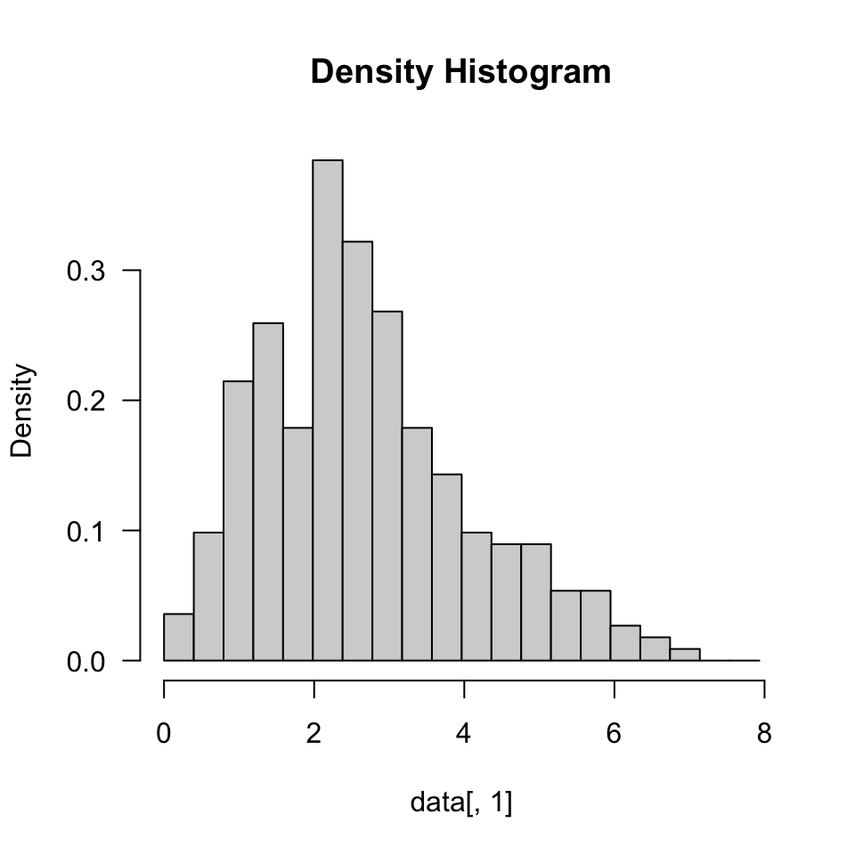

```r
f = kde(data[,1])  # kde() model will select the best bandwidth,
bw = f$h    # use f$h to see what's the best bandwidth = 0.3910206
bks = seq(0, 8, by=bw)
hh = hist(data[,1], freq=FALSE, breaks=bks, las=1, main="Density Histogram")
```

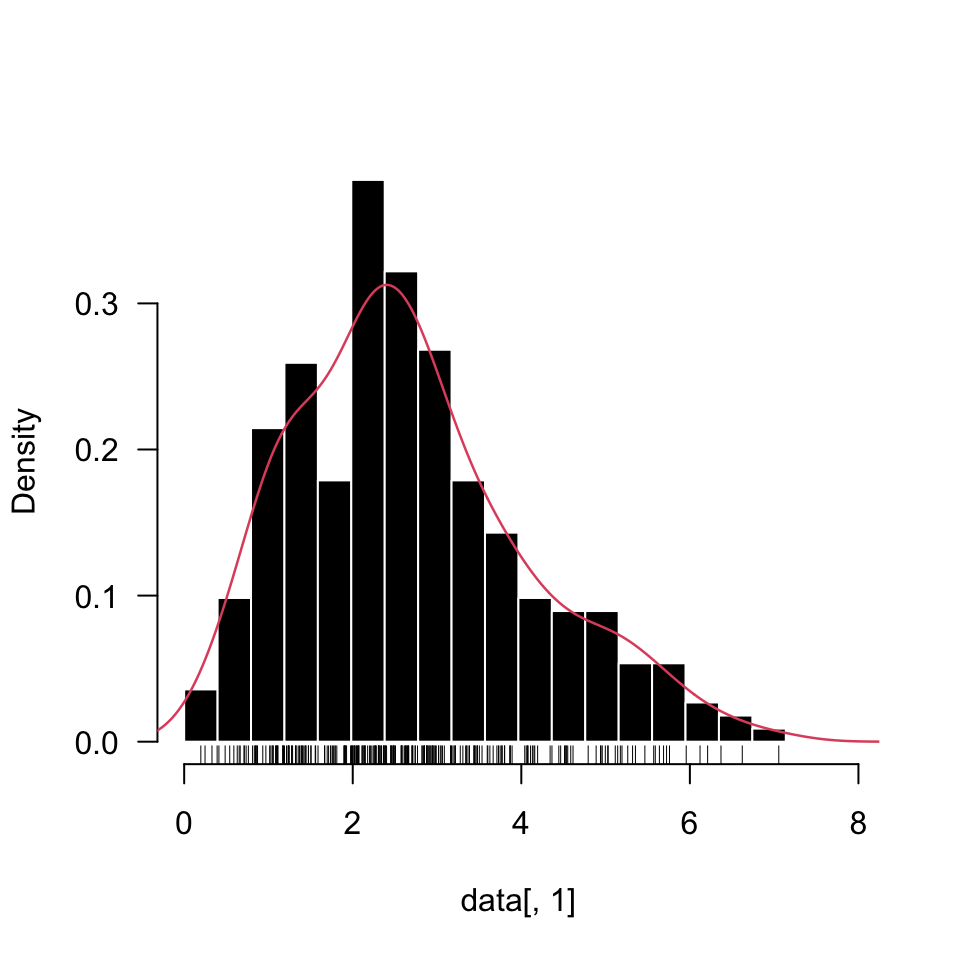

```r
plot(hh, freq=FALSE, ylim=c(0, max(c(hh$density, f$estimate))),
     las=1, main='', border='white', col='black')
rug(jitter(data[,1]))
lines(f$eval.points, f$estimate, col=2, lwd=1.25)
```

the bandwidth I chose is 0.3910206, which is the result of kde(), because kde will automatically chose the best bandwidth, after plug in the function, I just need to use $h to see what’s the best bandwidth in this case.

5. Which model do you prefer, the parametric or KDE?

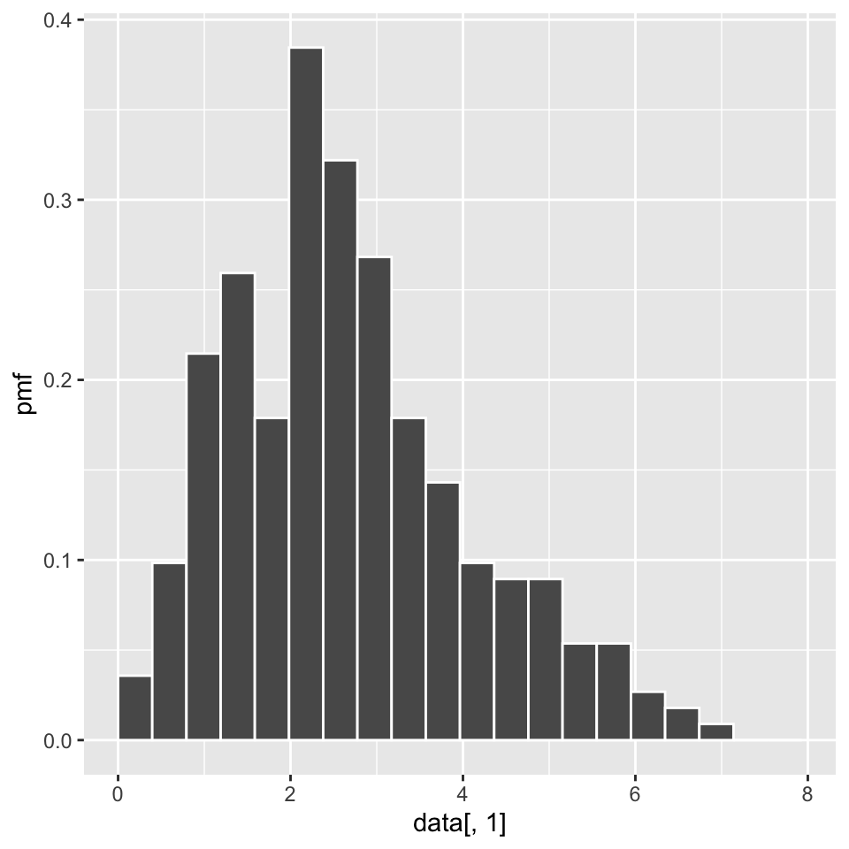

```r
g1 = ggplot() +  geom_histogram(aes(x=data[,1], y=after_stat(density)), breaks = bks, color="white")  +labs(y = "pmf")
g1
```

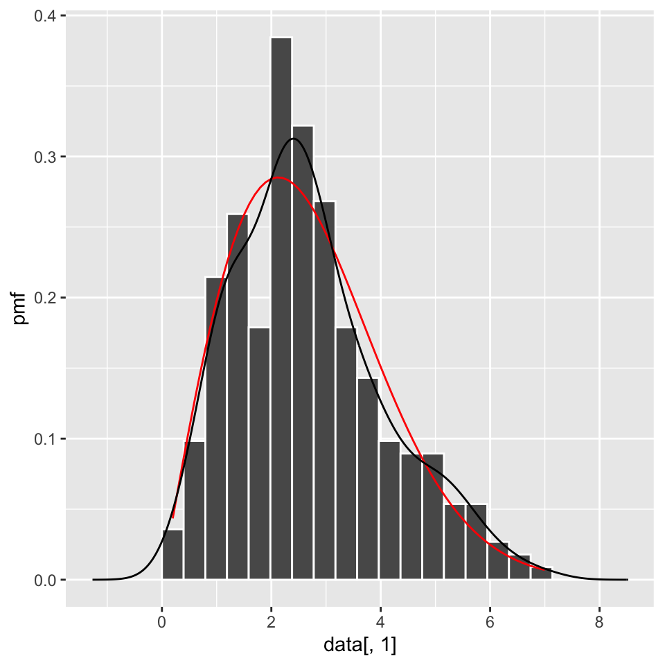

```r
g2 =  geom_line(aes(x,y), data=model, color="red", alpha=2)
g3 =  geom_line(aes(x=f$eval.points,y=f$estimate), color="black", alpha=2)
g1 + g2 + g3
```

In this case, the red line is parametric and KDE is the black line, I think i will perfer KDE more, because the line fit more smoothly than the red one. In addition to that, it is also depends on what task I’m working on, for example, KDE is better when I want to learn something about the phenomenon behind the data, while parametric is better if I want to know if the data and model agree or not.

reference used for this question: https://stats.stackexchange.com/questions/32970/advantage-of-kernel-density-estimation-over-parametric-estimation

### Problem 5.2: Interstate Crash Density

Interstate 64 (I-64) is a major east-west road that passes just south of Charlottesville. Where and when are the most dangerous places/times to be on I-64? The crash data (link below) gives the mile marker and fractional time-of-week for crashes that occurred on I-64 between mile marker 87 and 136 in 2016. The time-of-week data takes a numeric value of *<dow>.<hour/24>*, where the dow starts at 0 for Sunday (6 for Sat) and the decimal gives the time of day information. Thus `time=0.0417` corresponds to Sun at 1am and `time=6.5` corresponds to Sat at noon).

- **Crash Data**: https://mdporter.github.io/SYS6018/data/crashes16.csv
1. Extract the crashes and make a scatter plot with mile marker on x-axis and time on y-axis.

```r
df_2 = read_csv("crashes16.csv")
```

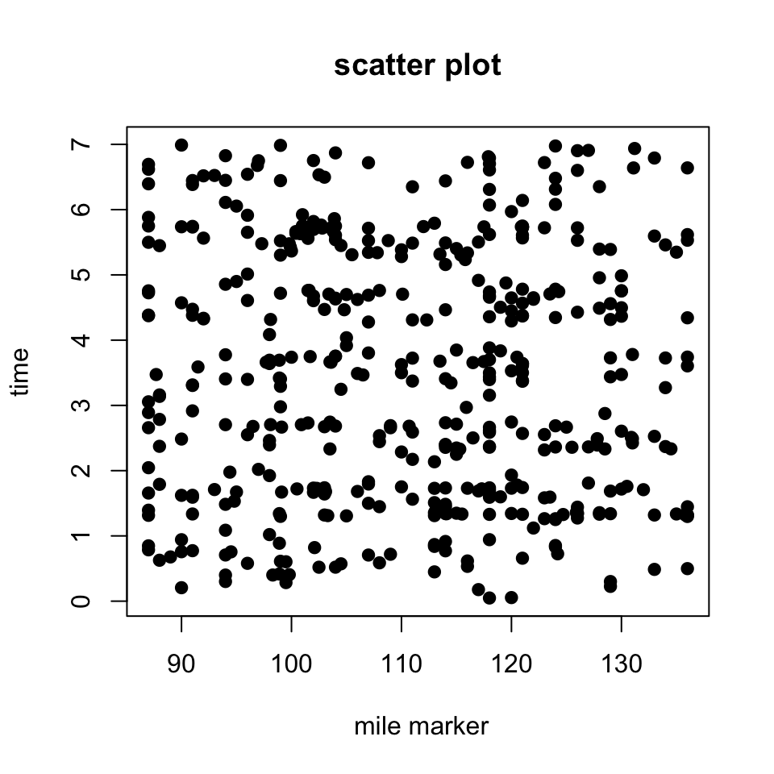

```r
plot(df_2$mile,df_2$time, main="scatter plot",
     xlab=" mile marker", ylab=" time ", pch=19)
```

2. Use KDE to estimate the *mile marker* density. Report the bandwidth and plot the density estimate.

```r
# 5.2 b
#---------------------------------------------------------------------------#
#-- KDE for estimate the mile marker density.
#---------------------------------------------------------------------------#

#-- KDE
f_1 = kde(df_2$mile)
f_1$h  # 2.894092
```

```
#> [1] 2.894092
```

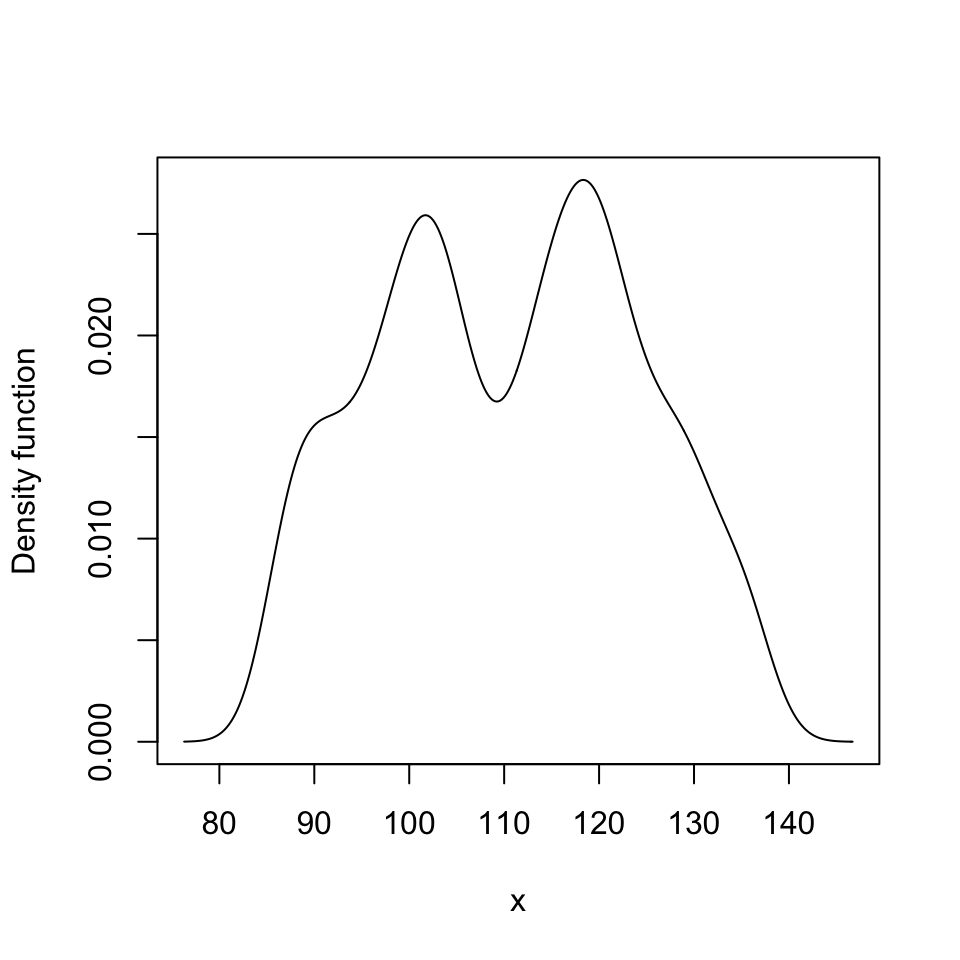

```r
plot(f_1)
```

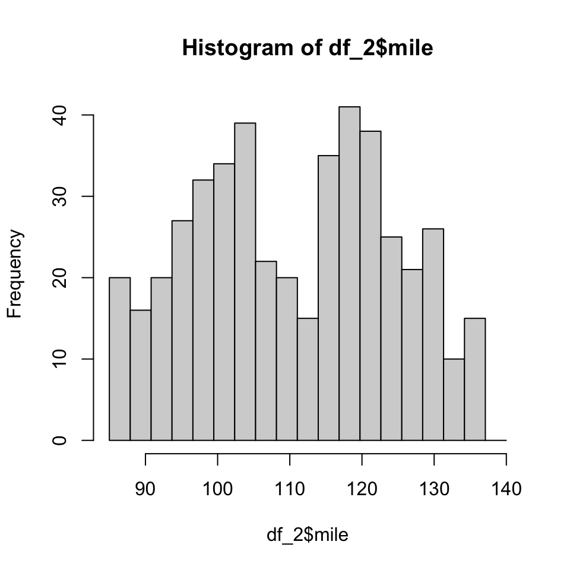

```r
#-- Histogram
bw_1 = f_1$h                      # binwidth parameter
bks_1 = seq(85, 140, by=bw_1)   # create a sequence of numbers
hh_1 = hist(df_2$mile,  breaks=bks_1)# histogram object
```

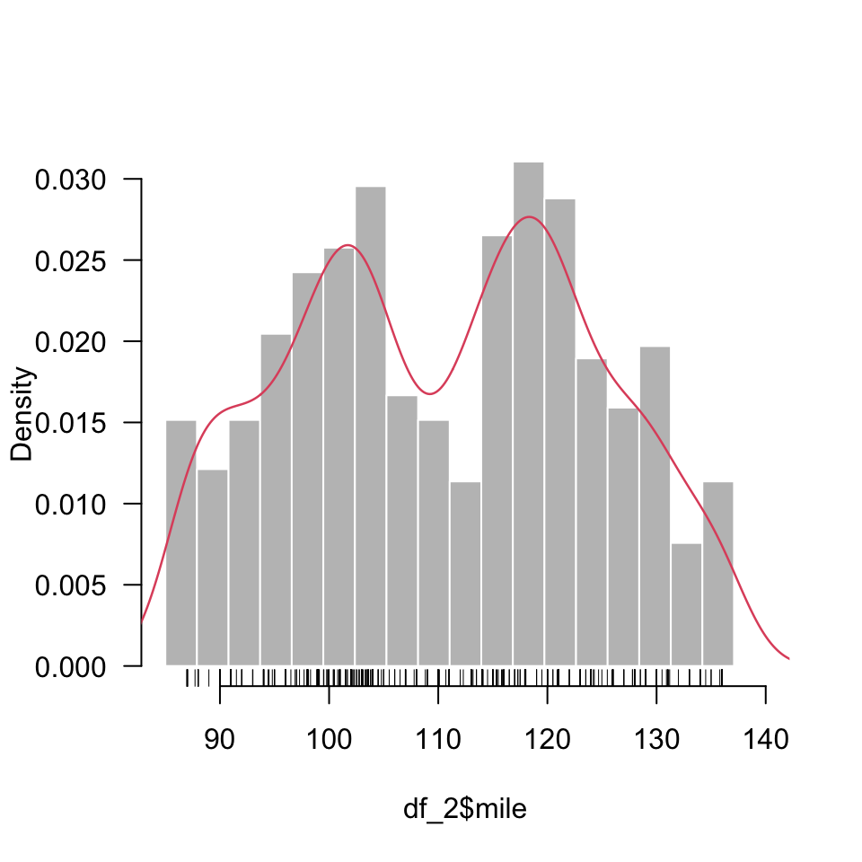

```r
#-- KDE
#f_1 = kde(df_2$mile, h=bw_1/3)
#plot(f_1)

#-- Plot hist and kde
plot(hh_1, freq=FALSE, ylim=c(0, max(c(hh_1$density, f_1$estimate))),
     las=1, main='', border='white', col='grey75')
rug(jitter(df_2$mile))
lines(f_1$eval.points, f_1$estimate, col=2, lwd=1.25)
```

the bandwidth is 2.894092, kde() function will select the best bandwidth, so after use the function, then use $h to find it.

3. Use KDE to estimate the temporal *time-of-week* density. Report the bandwidth and plot the density estimate.

```r
# 5.3 c

#---------------------------------------------------------------------------#
#-- KDE for estimate the temporal time of week density
#---------------------------------------------------------------------------#
#-- KDE
f_2 = kde(df_2$time)
f_2$H # 0.1715011
```

```
#> [1] 0.1715011
```

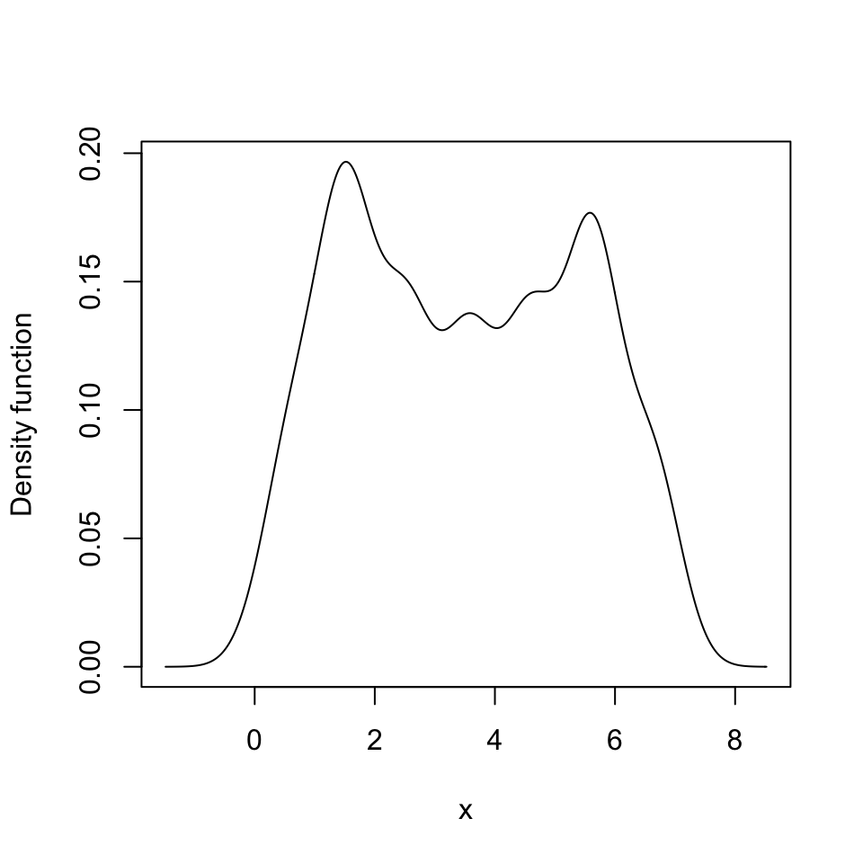

```r
#f_2$h
plot(f_2)
```

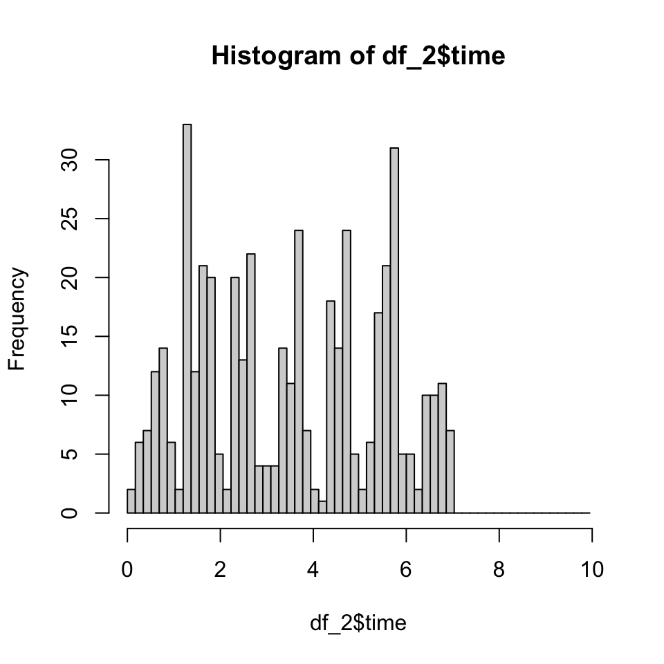

```r
#-- Histogram
bw_2 = f_2$H                      # binwidth parameter
bks_2 = seq(0, 10, by=bw_2)   # create a sequence of numbers
hh_2 = hist(df_2$time,  breaks=bks_2)# histogram object
```

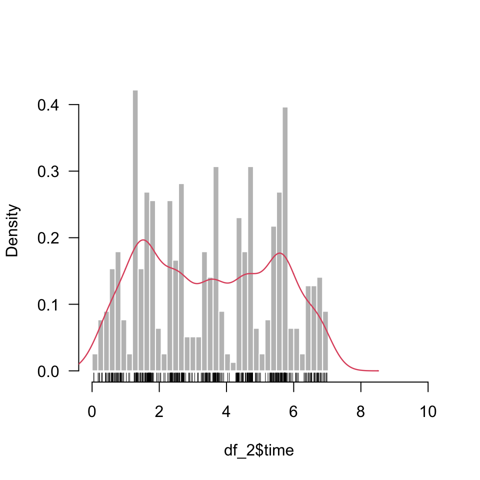

```r
#-- Plot hist and kde
plot(hh_2, freq=FALSE, ylim=c(0, max(c(hh_2$density, f_2$estimate))),
     las=1, main='', border='white', col='grey75')
rug(jitter(df_2$time))
lines(f_2$eval.points, f_2$estimate, col=2, lwd=1.25)
```

the bandwidth is 0.1715011, kde() function will select the best bandwidth, so after use the function, then use $H to find it.

4. Use KDE to estimate the bivariate mile-time density. What are the bandwidth parameters? Plot the bivariate density estimate.

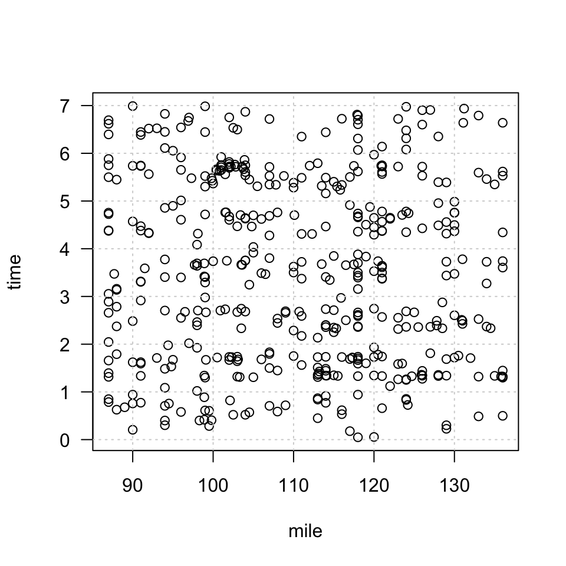

```r
# 5.3 d
#---------------------------------------------------------------------------#
#-- KDE for estimate the bivariate mile-time density
#---------------------------------------------------------------------------#

#-- Plot: Base R
plot(df_2, las=1); grid()
```

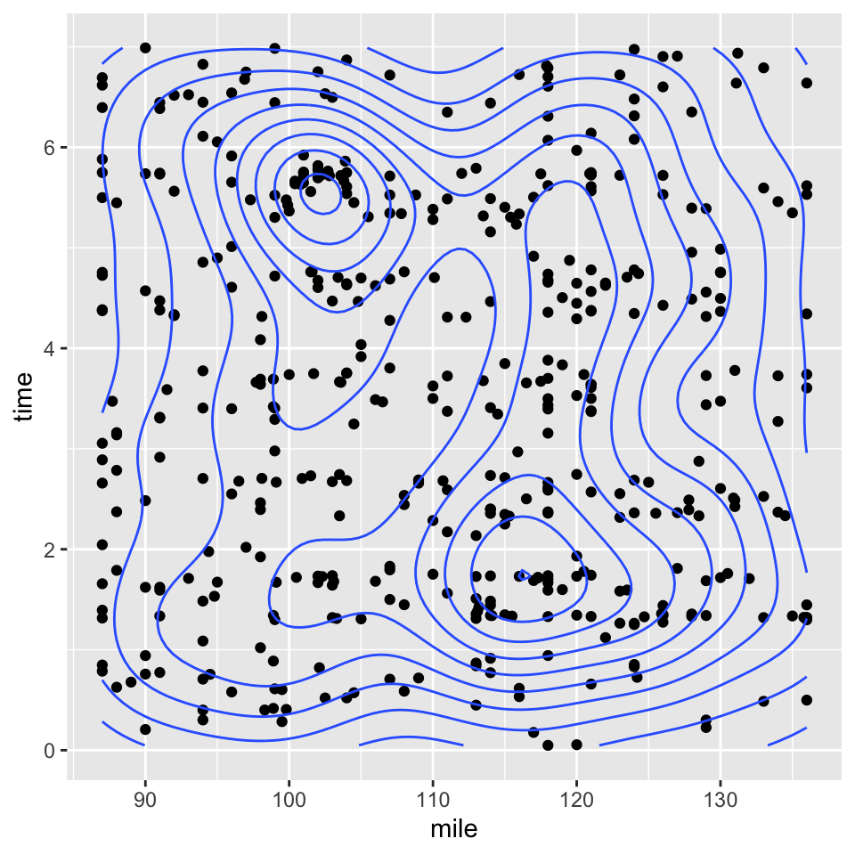

```r
#-- Plot: ggplot
ggplot(df_2, aes(mile, time)) + geom_point() +
  geom_density_2d() # geom_density2d_filled(), geom_contour_filled(), ...
```

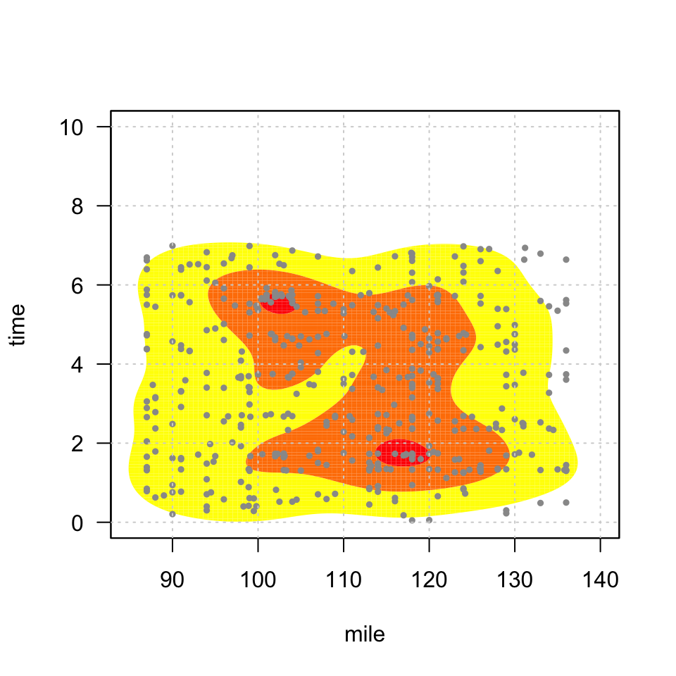

```r
#-- MV KDE: Unconstrained
H1 = Hscv(df_2)                  # smoothed cross-validation bw estimator
f1 = kde(df_2, H=H1)             # use H for multivariate data

plot(f1,
     cont = c(5, 50, 95),                        # set contour levels
      display = "filled.contour",                # use filled contour
     las=1, xlim = c(85, 140), ylim=c(0, 10))  # set asthetics
points(df_2, pch=19, cex=.5, col='grey60')           # add points
grid()                                            # add grid lines
```

```r
H1 # this is the bandwidth
```

```
#>            [,1]       [,2]
#> [1,] 25.9921201 -0.1523207
#> [2,] -0.1523207  0.3660496
```

the bandwidth is the output of H1.

5. Based on the estimated density, approximate the most dangerous mile marker and time-of-week.

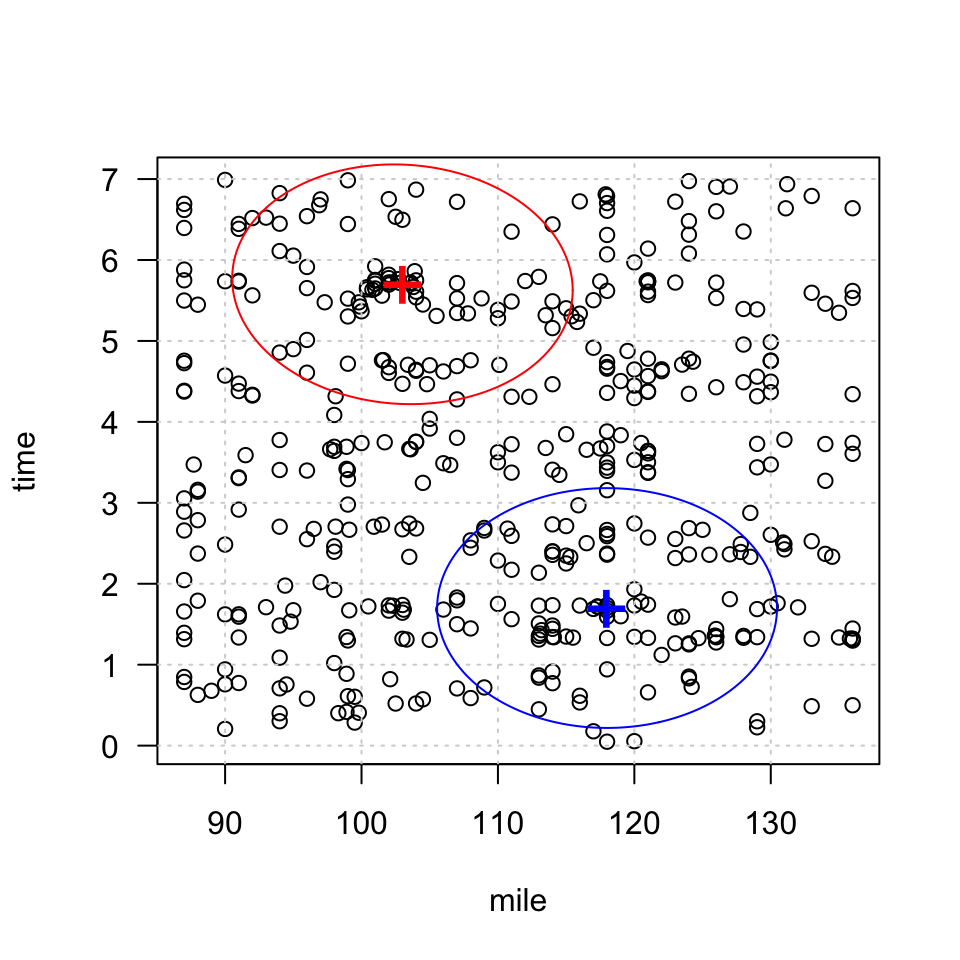

```r
#---------------------------------------------------------------------------#
#-- based on the estimated density, approximate the most dangerous mile marker and time of week
#---------------------------------------------------------------------------#

H1 = Hscv(df_2)
H2 = Hscv.diag(df_2)


#---------------------------------------------------------------------------#
#-- Visualize kernel shapes
#---------------------------------------------------------------------------#
plot(df_2, las=1); grid()

#-- Add 95% confidence ellipse for *unconstrained* at location (103, 5.7)

points(103, 5.7, pch="+", col="red", cex=2.5)
mixtools::ellipse(mu=c(103, 5.7),
                  sigma=H1,
                  alpha = .05, col="red")

#-- Add 95% confidence ellipse for *product kernel* at location (118, 1.7))

points(118, 1.7, pch="+", col="blue", cex=2.5)
mixtools::ellipse(mu=c(118, 1.7),
                  sigma=H2,
                  alpha = .05, col="blue")
```

#reference: participated in a group meeting around 20 people on Oct 7th. Orignized in Slack by Clair.